# Data Exploration Analysis: 2016 Presidential Election Example

Predicting the behavior of U.S voters is complicated for numerous reasons in spite of the incredible effort done to collect data as well as analyze, and understand many available datasets.

# Background

In 2012 the U.S. Presidential Election results were not a surprise to many in the nation. Nate Silver, statistician and founder of 538, was able to correctly predict the outcome desipite doubts of his approach.

However, the 2016 election was a surprise to almost everyone, Nate Silver included. His failure to predict became proof to many that even the most cutting edge technology is not good enough in terms of predictions.

Various factors make voter behavior prediction (and thus election forecasting) a hard problem. First, there may be changes in voting decisions over time. As time progresses, voting intentions are prone to changes. There are both measurable and unmeasurable, or national changes that may occur and change people’s decisions on who to vote for. Thus, the data obtained may not be the actual candidates that voters will vote for on election day. Another problem is that the sample may not always be random, and voters may not answer truthfully during these surveys. For instance, many people may not pick up for phone surveys, or may lie about who they are going to vote for. Finally, it is difficult to predict voter turnout.

There were many issues that could have led to poor predictions such as the following:

In 2016, various polls were missed and the errors were spread unevenly. There was a turnout problem in the Democratic side, so the turnout models were very off in many states. Also, it seems that Trump gained more support from undecided voters, or voters who were supporting a third-party candidate.

To make future predictions better, voter demographic information should be taken into account since it was observed that in states where there are more whites without college degrees, the more Trump outperformed his polls. By placing more emphasis on voter demographic information, we may better predict the factors that affect voter choice the most, and categorize them into respective groups.

However, for the purposes of this example we will only take a breif look at the data instead of using it to make models and predictions. We will also explore how to use the census data to create U.S. maps with R along with hw to color code the map by the winner of the election at the state/county level using election data.

# Data

```r
## First we read data and convert candidate from string to factor
#Notice we use the function `read_delim()` to read in our downloaded data. "Delim" is short for delimiter which is what is used within the file to separate the data.

# Election_raw contains the number of votes each candidate received in each state. The delimiters in this dataset are commas.
election_raw <- read_delim("data/election/election.csv", delim = ",") %>% mutate(candidate=as.factor(candidate))

# Census_meta contains details on each feature of the census dataset. The delimiters in this dataset are semicolons.
census_meta <- read_delim("data/census/metadata_edit.csv", delim = ",", col_names = TRUE)

#Census contains census data for each census tract (subsection of counties). The delimeters in this dataset are commas.
census <- read_delim("data/census/census.csv", delim = ",")
```

## Election data

**The meaning of each column in `election_raw` is relatively clear aside from `fips` which is short for Federal Information Processing Standard. It is the code assigned to each U.S. county.**

In our dataset, `fips` values denote the area (US, state, or county) that each row of data represent. For example, `fips` value of 6037 denotes Los Angeles County.

Here we will take a look at the number of votes for each candidate in Los Angeles County using `kable()`.

```r
#The function `kable()` is used to generate tables formatted specifically for html output files

#The "%>%" is called a pipe. It allows us to edit data/variables in multiple ways at once.
kable(election_raw %>%
        #filter by county
        filter(county == "Los Angeles County"))  %>%
        #add styling to the table using bootstrap options
        kable_styling(bootstrap_options = c("striped", "hover", "condensed", "responsive"), full_width=FALSE)
```

| county | fips | candidate | state | votes |
| --- | --- | --- | --- | --- |
| Los Angeles County | 6037 | Hillary Clinton | CA | 2464364 |
| Los Angeles County | 6037 | Donald Trump | CA | 769743 |
| Los Angeles County | 6037 | Gary Johnson | CA | 88968 |
| Los Angeles County | 6037 | Jill Stein | CA | 76465 |
| Los Angeles County | 6037 | Gloria La Riva | CA | 21993 |

Some rows in `election_raw` are summary rows and these rows have `county` value of `NA`. There are two kinds of summary rows:

- Federal-level summary rows have `fips` value of `US`.
- State-level summary rows have names of each states as `fips` value.

```r
election_raw <- election_raw %>%
  filter(fips !="2000")
```

We exclude fips=2000 because it represents Alaska. Alaska does not have counties, so that is why fips=2000 is the same as fips=AK.

## Census data

Following is the first few rows of the `census` data:

```r
#The function `head()` outputs the first 5 rows of a dataset.
kable(census %>% head, "html")  %>%
  kable_styling(bootstrap_options = c("striped", "hover", "condensed", "responsive"), full_width=FALSE) %>%
  scroll_box(width = "100%")
```

| CensusTract | State | County | TotalPop | Men | Women | Hispanic | White | Black | Native | Asian | Pacific | Citizen | Income | IncomeErr | IncomePerCap | IncomePerCapErr | Poverty | ChildPoverty | Professional | Service | Office | Construction | Production | Drive | Carpool | Transit | Walk | OtherTransp | WorkAtHome | … |
| --- | --- | --- | --- | --- | --- | --- | --- | --- | --- | --- | --- | --- | --- | --- | --- | --- | --- | --- | --- | --- | --- | --- | --- | --- | --- | --- | --- | --- | --- | --- |
| 1001020100 | Alabama | Autauga | 1948 | 940 | 1008 | 0.9 | 87.4 | 7.7 | 0.3 | 0.6 | 0.0 | 1503 | 61838 | 11900 | 25713 | 4548 | 8.1 | 8.4 | 34.7 | 17.0 | 21.3 | 11.9 | 15.2 | 90.2 | 4.8 | 0 | 0.5 | 2.3 | 2.1 | … |
| 1001020200 | Alabama | Autauga | 2156 | 1059 | 1097 | 0.8 | 40.4 | 53.3 | 0.0 | 2.3 | 0.0 | 1662 | 32303 | 13538 | 18021 | 2474 | 25.5 | 40.3 | 22.3 | 24.7 | 21.5 | 9.4 | 22.0 | 86.3 | 13.1 | 0 | 0.0 | 0.7 | 0.0 | … |
| 1001020300 | Alabama | Autauga | 2968 | 1364 | 1604 | 0.0 | 74.5 | 18.6 | 0.5 | 1.4 | 0.3 | 2335 | 44922 | 5629 | 20689 | 2817 | 12.7 | 19.7 | 31.4 | 24.9 | 22.1 | 9.2 | 12.4 | 94.8 | 2.8 | 0 | 0.0 | 0.0 | 2.5 | … |
| 1001020400 | Alabama | Autauga | 4423 | 2172 | 2251 | 10.5 | 82.8 | 3.7 | 1.6 | 0.0 | 0.0 | 3306 | 54329 | 7003 | 24125 | 2870 | 2.1 | 1.6 | 27.0 | 20.8 | 27.0 | 8.7 | 16.4 | 86.6 | 9.1 | 0 | 0.0 | 2.6 | 1.6 | … |
| 1001020500 | Alabama | Autauga | 10763 | 4922 | 5841 | 0.7 | 68.5 | 24.8 | 0.0 | 3.8 | 0.0 | 7666 | 51965 | 6935 | 27526 | 2813 | 11.4 | 17.5 | 49.6 | 14.2 | 18.2 | 2.1 | 15.8 | 88.0 | 10.5 | 0 | 0.0 | 0.6 | 0.9 | … |
| 1001020600 | Alabama | Autauga | 3851 | 1787 | 2064 | 13.1 | 72.9 | 11.9 | 0.0 | 0.0 | 0.0 | 2642 | 63092 | 9585 | 30480 | 7550 | 14.4 | 21.9 | 24.2 | 17.5 | 35.4 | 7.9 | 14.9 | 82.7 | 6.9 | 0 | 0.0 | 6.0 | 4.5 | … |

And the names of each of the features included in the `census` data:

```r
colnames(census)
```

```
##  [1] "CensusTract"     "State"           "County"
##  [4] "TotalPop"        "Men"             "Women"
##  [7] "Hispanic"        "White"           "Black"
## [10] "Native"          "Asian"           "Pacific"
## [13] "Citizen"         "Income"          "IncomeErr"
## [16] "IncomePerCap"    "IncomePerCapErr" "Poverty"
## [19] "ChildPoverty"    "Professional"    "Service"
## [22] "Office"          "Construction"    "Production"
## [25] "Drive"           "Carpool"         "Transit"
## [28] "Walk"            "OtherTransp"     "WorkAtHome"
## [31] "MeanCommute"     "Employed"        "PrivateWork"
## [34] "PublicWork"      "SelfEmployed"    "FamilyWork"
## [37] "Unemployment"
```

### Census data: column metadata

Column information is given in `metadata`.

```r
#First change the feature names so they are more descriptive
census_meta_1 <-census_meta

#Change the names so that they are more descriptive
names(census_meta_1)[1:3]=c("Variable","Description","Data Type")

#Plot data using `formattable`
formattable(census_meta_1)
```

| Variable | Description | Data Type |
| --- | --- | --- |
| State | State or DC or Puerto Rico | string |
| County | County or county equivalent | string |
| TotalPop | Total population | numeric |
| Men | Number of men | numeric |
| Women | Number of women | numeric |
| Hispanic | % of population that is Hispanic/Latino | numeric |
| White | % of population that is white | numeric |
| Black | % of population that is black | numeric |
| Native | % of population that is Native American or Native Alaskan | numeric |
| Asian | % of population that is Asian | numeric |
| Pacific | % of population that is Native Hawaiian or Pacific Islander | numeric |
| Citizen | Number of citizens | numeric |
| Income | Median household income (USD) | numeric |
| IncomeErr | Median household income error (USD) | numeric |
| IncomePerCap | Income per capita (USD) | numeric |
| IncomePerCapErr | Income per capita error (USD) | numeric |
| Poverty | % under poverty level | numeric |
| ChildPoverty | % of children under poverty level | numeric |
| Professional | % employed in management, business, science, and arts | numeric |
| Service | % employed in service jobs | numeric |
| Office | % employed in sales and office jobs | numeric |
| Construction | % employed in natural resources, construction, and maintenance | numeric |
| Production | % employed in production, transportation, and material movement | numeric |
| Drive | % commuting alone in a car, van, or truck | numeric |
| Carpool | % carpooling in a car, van, or truck | numeric |
| Transit | % commuting on public transportation | numeric |
| Walk | % walking to work | numeric |
| OtherTransp | % commuting via other means | numeric |
| WorkAtHome | % working at home | numeric |
| MeanCommute | Mean commute time (minutes) | numeric |
| Employed | % employed (16+) | numeric |
| PrivateWork | % employed in private industry | numeric |
| PublicWork | % employed in public jobs | numeric |
| SelfEmployed | % self-employed | numeric |
| FamilyWork | % in unpaid family work | numeric |
| Unemployment | Unemployment rate (%) | numeric |

## Data wrangling

**Data set name changes**

```
* Federal-level summary into a `election_federal`.

* State-level summary into a `election_state`.

* Only county-level data is to be in `election_county`.
```

```r
#In `election_raw`, federal level data has fips="US", and county="NA"
election_federal<-filter(election_raw, is.na(county) & fips=="US")

#In `election_raw`, state level data only has county="NA"
election_state <- filter(election_raw, is.na(county) & fips !="US")

#In `election_raw`, county level data has values for county
election_county<-election_raw %>% filter(!is.na(county))
```

**The county and state winners:**

```r
#The winner of each county
county_winner<-election_county %>%
  group_by(fips) %>%
    #group by county
    mutate(total=sum(votes), pct=votes/total) %>%
    #We want the top row because it shows the winner of the county
    top_n(1)
county_winner
```

```
## # A tibble: 3,111 x 7
## # Groups:   fips [3,111]
##    county             fips  candidate       state   votes   total   pct
##    <chr>              <chr> <fct>           <chr>   <int>   <int> <dbl>
##  1 Los Angeles County 6037  Hillary Clinton CA    2464364 3421533 0.720
##  2 Cook County        17031 Hillary Clinton IL    1611946 2156395 0.748
##  3 Maricopa County    4013  Donald Trump    AZ     747361 1536743 0.486
##  4 Harris County      48201 Hillary Clinton TX     707914 1305434 0.542
##  5 San Diego County   6073  Hillary Clinton CA     735476 1291078 0.570
##  6 Orange County      6059  Hillary Clinton CA     609961 1186203 0.514
##  7 King County        53033 Hillary Clinton WA     718322  998499 0.719
##  8 Miami-Dade County  12086 Hillary Clinton FL     624146  980204 0.637
##  9 Broward County     12011 Hillary Clinton FL     553320  831950 0.665
## 10 Kings County       36047 Hillary Clinton NY     640553  800393 0.800
## # ... with 3,101 more rows
```

```r
#The winner of each state
state_winner<-election_state %>%
  group_by(fips) %>%
  mutate(total=sum(votes), pct=votes/total) %>%
  top_n(1)
state_winner
```

```
## # A tibble: 52 x 7
## # Groups:   fips [52]
##    county fips  candidate       state   votes    total   pct
##    <chr>  <chr> <fct>           <chr>   <int>    <int> <dbl>
##  1 <NA>   CA    Hillary Clinton CA    8753788 14060856 0.623
##  2 <NA>   FL    Donald Trump    FL    4617886  9419886 0.490
##  3 <NA>   TX    Donald Trump    TX    4685047  8917965 0.525
##  4 <NA>   NY    Hillary Clinton NY    4556124  7660190 0.595
##  5 <NA>   PA    Donald Trump    PA    2970733  6115402 0.486
##  6 <NA>   IL    Hillary Clinton IL    3090729  5523142 0.560
##  7 <NA>   OH    Donald Trump    OH    2841005  5480173 0.518
##  8 <NA>   MI    Donald Trump    MI    2279543  4790329 0.476
##  9 <NA>   NC    Donald Trump    NC    2362631  4682073 0.505
## 10 <NA>   GA    Donald Trump    GA    2089104  4092373 0.510
## # ... with 42 more rows
```

# Visualization

Visualization is crucial for gaining insight and intuition during data mining. We will map our data onto maps using `ggplot2`.

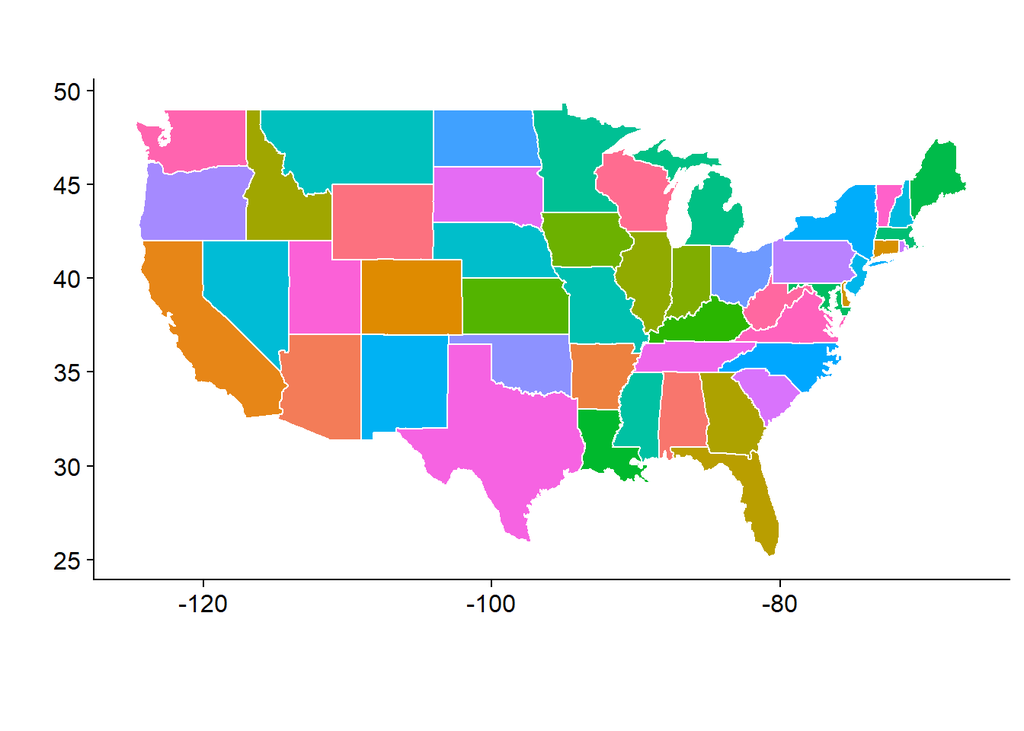

```r
#includes information nessecary to draw maps of US states
states <- map_data("state")

#ggplot draws the map
 ggplot(data = states) +
#   #geom_polygon shows the boundaries between states (colored in white)
  geom_polygon(aes(x = long, y = lat, fill = region, group = group), color = "white") +
#   #coord_fixed ensures everything is correctly scaled
  coord_fixed(1.3) +
#   #no legend as it is unnecessary here
  guides(fill=FALSE) +
  xlab("")+ ylab("")
```

The variable `states` contain information to draw white polygons, and fill-colors are determined by `region`.

**County-level map colored by county:**

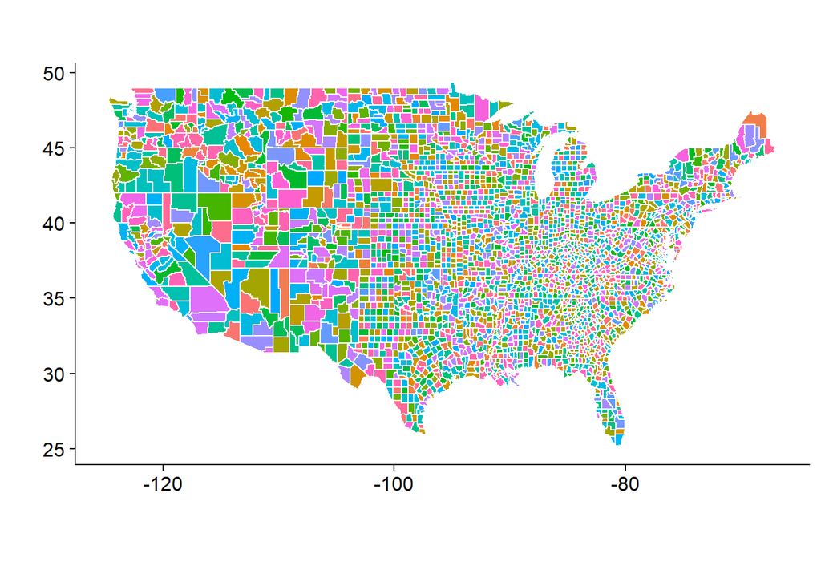

```r
#includes information nessecary to draw maps of US counties
counties = map_data("county")

ggplot(data = counties) +
  geom_polygon(aes(x = long, y = lat, fill = subregion, group = group), color = "white") +
  coord_fixed(1.3) +
  guides(fill=FALSE)+
  xlab("")+ylab("")
```

**Next we colored the map by the winning candidate for each state.** First, combine `states` variable and `state_winner` we created earlier using `left_join()`. Note that `left_join()` needs to match up values of states to join the tables. A call to `left_join()` takes all the values from the first table and looks for matches in the second table. If it finds a match, it adds the data from the second table; if not, it adds missing values:

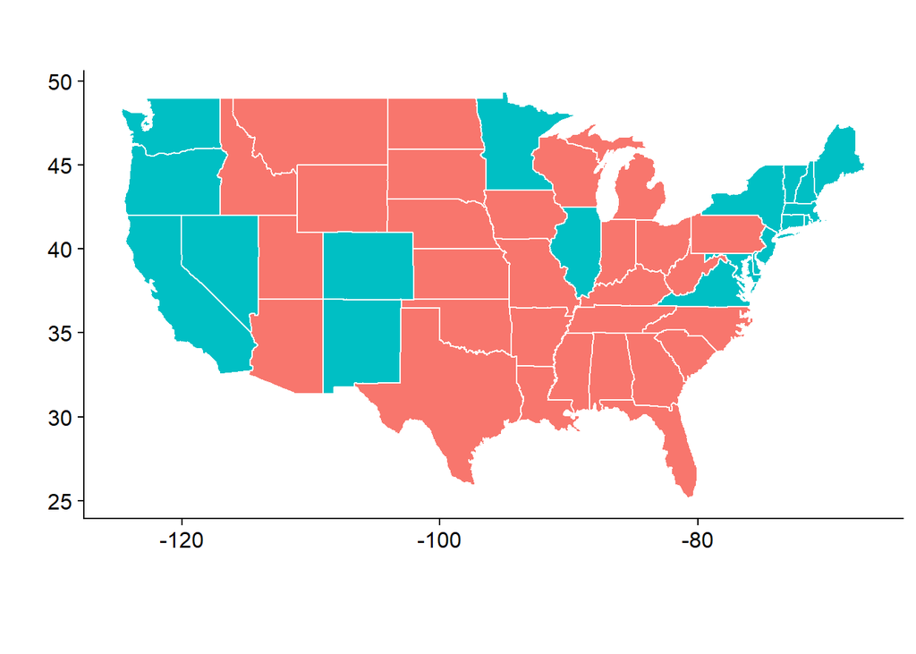

```r
#create a new column for 'states'
fips = state.abb[match(states$region, tolower(state.name))]
states <- states %>% mutate(fips=fips)

#combine data so as to color states based on election winner
combinestate <- left_join(states, state_winner, by="fips")

ggplot(data=combinestate) +
  geom_polygon(aes(x = long, y = lat, fill = candidate, group = group), color = "white") +
   coord_fixed(1.3) +
  guides(fill=FALSE) +
  xlab("") + ylab("")
```

**And the county:**

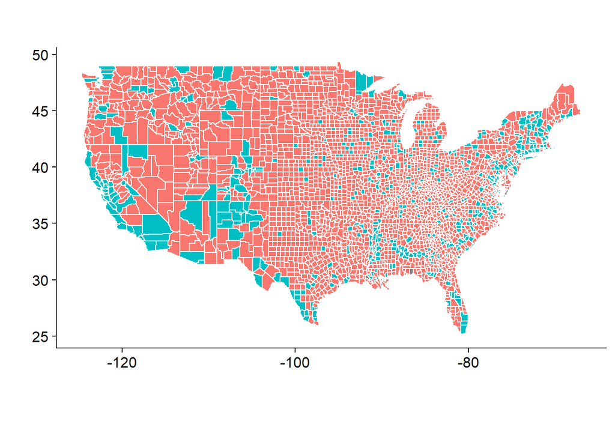

```r
#Use function `county.fips` from the maps library
county<-maps::county.fips%>%

#Separate the feature "polyname" into "region" and "subregion"
  separate(polyname,c("region","subregion"),sep=",")

#change fips into a numeric type variable
county_winner<-transform(county_winner,fips=as.numeric(fips))

#join the datasets "county" and "county_winner" on "fips"
county<-left_join(county,county_winner, by="fips")

#join the datasets "counties" and "county" on "fips"
county.locs<-left_join(counties,county,by="subregion")

#Similar to abbove
ggplot(data = county.locs) +
  geom_polygon(aes(x = long, y = lat, fill = candidate, group = group), color = "white") +
  coord_fixed(1.3) +
  guides(fill=FALSE) +
  xlab("")+ylab("")
```

**The full list of presidential candidates and the number of votes the received in the general election:** There were 31 named presidential candidates in the 2016 elections (1 factor is dedicated to the unnamed candidates resulting in 32 “Candidates”, as seen in the plot below).

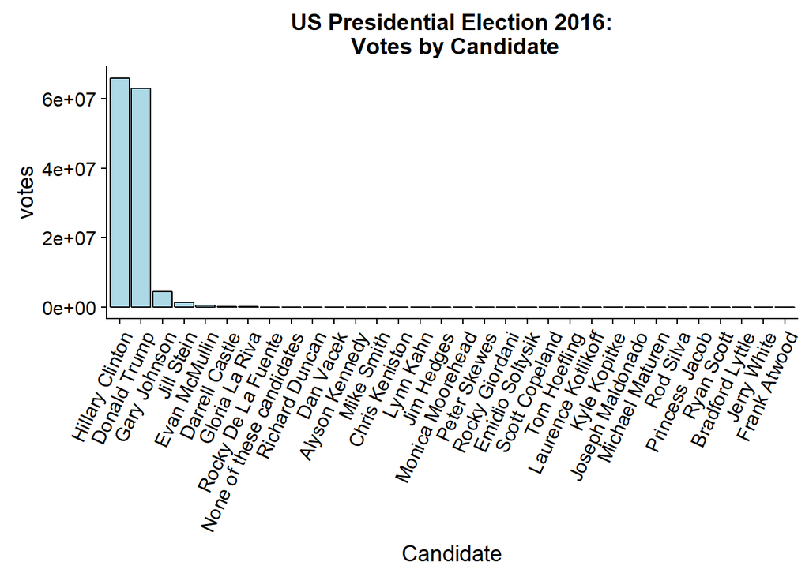

```r
#Use the federal election data to create a new dataset, grouped by votes
cand_vote_dat <-election_federal %>%group_by(votes)

#Order by number of votes
cand_vote_dat<-cand_vote_dat[order(cand_vote_dat$votes, decreasing = TRUE),]

#create histogram for number of votes per candidate
votes_hist<-ggplot(data=cand_vote_dat)+

                   #choose variables to display (x=candidates, y=votes)
            aes(cand_vote_dat$candidate, cand_vote_dat$votes) +

                    #make it a histogram, ordered by number of votes
            geom_histogram(aes(reorder(cand_vote_dat$candidate,
                             -cand_vote_dat$votes), cand_vote_dat$votes),
                              stat="identity",
                    #add color
                              color="black", fill="lightblue") +

                    #change the angle of x axis labels so they are readable
  theme(axis.text.x = element_text(angle = 65, hjust = 1)) +
                    #add axis names and title
  xlab("Candidate") +
  ylab("votes") +
  ggtitle("US Presidential Election 2016:\n Votes by Candidate")


#Exactly the same as above except log of votes to see the differences between the less popular candidates
log_votes_hist <-ggplot(data=cand_vote_dat)+
  aes(cand_vote_dat$candidate, log(cand_vote_dat$votes)) +
  geom_histogram(aes(reorder(cand_vote_dat$candidate,
                    -log(cand_vote_dat$votes)),
                     log(cand_vote_dat$votes)), stat="identity",
                      color="black", fill="lightblue") +
  theme(axis.text.x = element_text(angle = 65, hjust = 1)) +
  xlab("Candidate") +
  ylab("log(votes)") +
  ggtitle("US Presidential Election 2016:\n Log(votes) by Candidate")

#plot histograms side by side
votes_hist
```

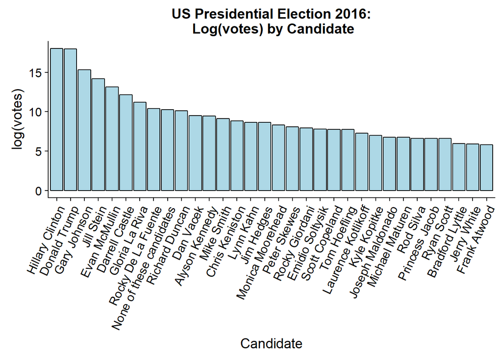

```r
log_votes_hist
```

## Summary

In this example we looked at how use multiple datasets and libraries to explore the 2016 U.S. Presidential Election through tables and visualizations. Many in the country and throughout the world did not expect Donald Trump to win. It leads to the question, “What made U.S. voters choose Donald Trump over Hilary Clinton when all the experts expected otherwise?”

In future chapters we will explore the data further to determine the factors that most determined a 2016 voter’s choice for president. In addition, we will delve into how we can improve polling so that our predictions in future elections are more accurate.